# PROYECTO 1: LIMPIEZA Y PREPROCESAMIENTO DE DATOS

Especialización en Inteligencia Artificial y Ciencia de Datos — UPTC

Daniel Rojas

14 de noviembre de 2026

# 1 Carga e Inspección Inicial del Conjunto de Datos

En esta etapa inicial se procede a verificar el entorno de archivos de trabajo, cargar el conjunto de datos de estudio y realizar un reconocimiento estructural preliminar de variables y dimensiones.

## 1.1 Verificación de archivos en el entorno

Se listan los archivos contenidos en el directorio `DATOS` para confirmar la disponibilidad del archivo fuente:

```r
list.files("../DATOS")    # Lectura de archivos en la carpeta DATOS
```

```
## [1] "dataset_clase_1.csv"
```

## 1.2 Carga del conjunto de datos

Se importa el archivo `dataset_clase_1.csv` en la sesión de trabajo asignándolo al data frame `data`:

```r
data <- read.csv("../DATOS/dataset_clase_1.csv", stringsAsFactors = FALSE)
```

## 1.3 Vista previa de la estructura de datos

A continuación se visualizan las dimensiones, los nombres de columnas y los tipos de datos:

```r
# Dimensión del dataset (filas x columnas)
dim(data)
```

```
## [1] 30 12
```

> **Interpretación:** El conjunto de datos original cuenta con **30 filas** (observaciones) y **12 columnas** (variables).

```r
# Nombres de las columnas
knitr::kable(colnames(data), caption = "Variables del dataset original")
```

Variables del dataset original

| x |
| --- |
| ID |
| Nombre |
| Apellido |
| Edad |
| Ingreso |
| Genero |
| Ciudad |
| Profesion |
| Nivel_Educativo |
| Estado_Civil |
| Hijos |
| Email |

```r
# Estructura y tipos de datos por columna
str(data)
```

```
## 'data.frame':    30 obs. of  12 variables:
##  $ ID             : int  1 2 3 4 5 6 7 8 9 10 ...
##  $ Nombre         : chr  "Juan" "Ana" "Carlos" "María" ...
##  $ Apellido       : chr  "Pérez" "Gómez" "Lopez" "Rodríguez" ...
##  $ Edad           : num  25 30 45 29 35 NA 25 40 22 28 ...
##  $ Ingreso        : num  1200 1500 3000 NA -2000 1800 1200 50000 1100 1300 ...
##  $ Genero         : chr  "MASCULINO" "Femenino" "MASCULINO" "FEMENINO" ...
##  $ Ciudad         : chr  "Bogotá" "Medellín" "Cali" "Bogotá" ...
##  $ Profesion      : chr  "Ingeniero" "Abogada" "Medico" "Docente" ...
##  $ Nivel_Educativo: chr  "Universitario" "Especialización" "Maestría" "Universitario" ...
##  $ Estado_Civil   : chr  "SOLTERO" "Casada" "CASADO" "Soltera" ...
##  $ Hijos          : int  0 1 2 0 3 0 0 2 0 0 ...
##  $ Email          : chr  "juanp@gmail.com" "ana.gomez@gmail.com" "carlosl@gmail.com" "maria@gmail.com" ...
```

### 1.3.1 Primeras y últimas observaciones

```r
knitr::kable(head(data, 5), caption = "Primeras 5 observaciones del conjunto de datos original")
```

Primeras 5 observaciones del conjunto de datos original

| ID | Nombre | Apellido | Edad | Ingreso | Genero | Ciudad | Profesion | Nivel_Educativo | Estado_Civil | Hijos | Email |
| --- | --- | --- | --- | --- | --- | --- | --- | --- | --- | --- | --- |
| 1 | Juan | Pérez | 25 | 1200 | MASCULINO | Bogotá | Ingeniero | Universitario | SOLTERO | 0 | juanp@gmail.com |
| 2 | Ana | Gómez | 30 | 1500 | Femenino | Medellín | Abogada | Especialización | Casada | 1 | ana.gomez@gmail.com |
| 3 | Carlos | Lopez | 45 | 3000 | MASCULINO | Cali | Medico | Maestría | CASADO | 2 | carlosl@gmail.com |
| 4 | María | Rodríguez | 29 | NA | FEMENINO | Bogotá | Docente | Universitario | Soltera | 0 | maria@gmail.com |
| 5 | Pedro | Martinez | 35 | -2000 | Masculino | bogotá | Comerciante | Bachiller | UNION LIBRE | 3 | pedro@gmail.com |

```r
knitr::kable(tail(data, 5), caption = "Últimas 5 observaciones del conjunto de datos original")
```

Últimas 5 observaciones del conjunto de datos original

|  | ID | Nombre | Apellido | Edad | Ingreso | Genero | Ciudad | Profesion | Nivel_Educativo | Estado_Civil | Hijos | Email |
| --- | --- | --- | --- | --- | --- | --- | --- | --- | --- | --- | --- | --- |
| 26 | 26 | Oscar | Gil | 37 | 1700 | MASCULINO | Medellín | Administrador | Universitario | Casado | 2 | oscar@gmail.com |
| 27 | 27 | Claudia | Pardo | 34 | 1550 | FEMENINO | Bogotá | Docente | Especialización | Casada | 1 | claudia@gmail.com |
| 28 | 28 | Ricardo | Acosta | 200 | 3000 | MASCULINO | Cali | Empresario | Maestría | Casado | 4 | ricardo@gmail.com |
| 29 | 29 | Lina | Bautista | 28 | 1300 | Femenino | Medellín | Diseñadora | Universitario | Soltera | 0 | lina@gmail.com |
| 30 | 30 | Juan | Pérez | 25 | 1200 | MASCULINO | Bogotá | Ingeniero | Universitario | SOLTERO | 0 | juanp@gmail.com |

# 2 Diagnóstico Univariado: Variables Cualitativas

El análisis de variables cualitativas o categóricas permite evaluar la cardinalidad, balance de clases y detectar anomalías en la captura de texto (inconsistencias tipográficas, fragmentación de niveles y faltas ortográficas).

## 2.1 Variable: `Profesion`

```r
tabla_profesion <- data.frame(sort(table(data$Profesion), decreasing = TRUE))
colnames(tabla_profesion) <- c("Profesion", "Frecuencia")
knitr::kable(tabla_profesion, align = c("l", "c"), caption = "Distribución de frecuencias: Profesión")
```

Distribución de frecuencias: Profesión

| Profesion | Frecuencia |
| --- | --- |
| Ingeniero | 8 |
| Docente | 3 |
| Estudiante | 3 |
| Abogada | 2 |
| Administrador | 2 |
| Comerciante | 2 |
| Contador | 2 |
| Diseñadora | 2 |
| Empresario | 2 |
| Psicologa | 2 |
| Ingeniera | 1 |
| Medico | 1 |

💡 Hallazgos Principales

- **Moda dominante:** *Ingeniero* representa la categoría dominante con más de una cuarta parte de la muestra (8 casos), triplicando a las subsiguientes (Docente y Estudiante con 3 casos cada una).
- **Alta dispersión y cardinalidad:** Fuera de la moda, la muestra se reparte en múltiples micro-categorías (de 1 a 3 casos), indicando alta fragmentación para una muestra reducida de solo 30 registros.
- **Empates frecuentes:** Siete categorías empatan con 2 observaciones, por lo que su ordenamiento es puramente alfabético.

⚠️ Problemas de Calidad de Datos Identificados

- **Inconsistencia de género gramatical:** Se registran formas femeninas como *“Abogada”*, *“Diseñadora”*, *“Psicologa”* y *“Ingeniera”* coexistiendo con formas masculinas (*“Ingeniero”*, *“Administrador”*, *“Contador”*). Esto fragmenta artificialmente la categoría *Ingeniería* en dos niveles.
- **Ausencia de tildes:** *“Psicologa”* carece de tilde ortográfica frente al estándar formal.
- **Variabilidad en digitación:** Riesgo de discrepancias de mayúsculas/minúsculas al igual que en las demás variables de texto.

## 2.2 Variable: `Genero`

```r
tabla_genero <- data.frame(sort(table(data$Genero), decreasing = TRUE))
colnames(tabla_genero) <- c("Genero", "Frecuencia")
knitr::kable(tabla_genero, align = c("l", "c"), caption = "Distribución de frecuencias: Género (Sin Depurar)")
```

Distribución de frecuencias: Género (Sin Depurar)

| Genero | Frecuencia |
| --- | --- |
| MASCULINO | 16 |
| Femenino | 8 |
| FEMENINO | 5 |
| Masculino | 1 |

🚨 Problema Crítico: Fragmentación por Mayúsculas y Minúsculas

La variable conceptualmente es binaria (2 niveles), pero se encuentra fragmentada en **4 niveles distintos** debido a digitación no estandarizada: `MASCULINO`, `Masculino`, `FEMENINO` y `Femenino`.

💡 Diagnóstico Estadístico

- **Moda unificada estimada:** Masculino acumula 17 de los 30 casos (56.7%).
- **Balance de clases:** Desbalance moderado (17 Masculino vs. 13 Femenino), adecuado para comparaciones estadísticas básicas.
- **Completitud:** 100% de los 30 registros poseen valor asignado (sin valores `NA`).

## 2.3 Variable: `Ciudad`

```r
tabla_ciudad <- data.frame(sort(table(data$Ciudad), decreasing = TRUE))
colnames(tabla_ciudad) <- c("Ciudad", "Frecuencia")
knitr::kable(tabla_ciudad, align = c("l", "c"), caption = "Distribución de frecuencias: Ciudad (Sin Depurar)")
```

Distribución de frecuencias: Ciudad (Sin Depurar)

| Ciudad | Frecuencia |
| --- | --- |
| Bogotá | 11 |
| Cali | 9 |
| Medellín | 8 |
| bogota | 1 |
| bogotá | 1 |

🚨 Problema Crítico: Fragmentación de la Capital (Bogotá)

La ciudad de Bogotá aparece registrada bajo tres etiquetas disímiles: **“Bogotá”** (mayúscula inicial con tilde), **“bogotá”** (minúscula con tilde) y **“bogota”** (minúscula sin tilde).

## 2.4 Variable: `Nivel_Educativo`

```r
tabla_educacion <- data.frame(sort(table(data$Nivel_Educativo), decreasing = TRUE))
colnames(tabla_educacion) <- c("Nivel Educativo", "Frecuencia")
knitr::kable(tabla_educacion, align = c("l", "c"), caption = "Distribución de frecuencias: Nivel Educativo")
```

Distribución de frecuencias: Nivel Educativo

| Nivel Educativo | Frecuencia |
| --- | --- |
| Universitario | 18 |
| Especialización | 6 |
| Maestría | 4 |
| Bachiller | 2 |

💡 Diagnóstico Estadístico

- **Moda y Mediana:** *Universitario* representa el 60% de la muestra (18 casos). La mediana acumulada se sitúa también en este nivel.
- **Alto perfil de formación:** El **93.3%** de las observaciones posee al menos educación universitaria completa, y un **33.3%** (10 personas) cuenta con formación de posgrado (Especialización o Maestría).
- **Categoría minoritaria:** *Bachiller* concentra únicamente 2 observaciones.
- **Calidad del dato:** No presenta anomalías tipográficas ni valores perdidos.

## 2.5 Variable: `Estado_Civil`

```r
tabla_civil <- data.frame(sort(table(data$Estado_Civil), decreasing = TRUE))
colnames(tabla_civil) <- c("Estado Civil", "Frecuencia")
knitr::kable(tabla_civil, align = c("l", "c"), caption = "Distribución de frecuencias: Estado Civil (Sin Depurar)")
```

Distribución de frecuencias: Estado Civil (Sin Depurar)

| Estado Civil | Frecuencia |
| --- | --- |
| Soltera | 10 |
| Casado | 8 |
| SOLTERO | 4 |
| Casada | 3 |
| Soltero | 2 |
| CASADO | 1 |
| Union libre | 1 |
| UNION LIBRE | 1 |

🚨 Problema Crítico: 8 Niveles Observados vs. 3 Reales

La variable sufre fragmentación por dos causas concurrentes:

   .
2. **Concordancia de género gramatical:** Registro segregado en `Soltero/Soltera` y `Casado/Casada`.

💡 Diagnóstico Estadístico

- **Moda consolidada:** Personas solteras (16 observaciones, 53.3%), seguidas por personas casadas (12 observaciones, 40.0%).
- **Unión libre:** Representa únicamente 2 casos (6.7%).
- **Completitud:** Sin datos faltantes.

# 3 Diagnóstico Univariado: Variables Cuantitativas

Las variables numéricas requieren un diagnóstico detallado de medidas de tendencia central, dispersión, asimetría y la detección rigurosa de errores de captura o valores atípicos (*outliers*).

## 3.1 Variable: `Ingreso`

```
##    Min. 1st Qu.  Median    Mean 3rd Qu.    Max.     NAs
##   -2000    1200    1325    3200    1625   50000       2
```

### 3.1.1 Tabla de Estadísticos Descriptivos

| Medida Estadística | Valor Observado | Diagnóstico e Interpretación Analítica |
| --- | --- | --- |
| **Mínimo** | **-2,000** | 🚨 **Error crítico de captura:** Valor negativo imposible para una variable de ingresos brutos. |
| **Primer Cuartil ($Q_1$)** | 1,200 | El 25% de la muestra percibe ingresos iguales o inferiores a 1,200. |
| **Mediana ($Q_2$)** | **1,325** | Valor central robusto: 50% de las observaciones gana menos de 1,325 y 50% más. |
| **Media Aritmética** | **3,200** | ⚠️ **Distorsión severa:** La media duplica la mediana debido a la influencia de un valor extremo. |
| **Tercer Cuartil ($Q_3$)** | 1,625 | El 75% percibe ingresos iguales o menores a 1,625. |
| **Máximo** | **50,000** | 🚨 **Valor extremo (Outlier severo):** Extremadamente distante del cuerpo central de datos. |
| **Valores Nulos ($NA$)** | 2 | Dos registros con información no diligenciada. |

⚠️ Diagnóstico de Distribución: La media ($3,200) no representa al grupo

La marcada brecha entre la media ($3,200) y la mediana ($1,325) evidencia un **fuerte sesgo positivo (hacia la derecha)**. Un solo registro anómalo de 50,000 distorsiona la media global en aproximadamente $+1,786$ unidades ($\frac{50000}{28} \approx 1786$). En distribuciones con esta asimetría, la mediana constituye el indicador adecuado de tendencia central.

### 3.1.2 Detección Formal de Outliers (Regla de Tukey)

Aplicando el criterio de $1.5 \times \text{IQR}$:
$$\text{IQR} = Q_3 - Q_1
= 1625 - 1200 = 425$$
$$\text{Límite
Inferior} = 1200 - (1.5 \times 425) = 562.5$$
$$\text{Límite Superior} = 1625 + (1.5 \times 425)
= 2262.5$$

- **$-2,000$:** Inconsistencia por debajo del límite inferior (error de captura).
- **$50,000$:** Atípico extremo por encima del límite superior.

### 3.1.3 Comportamiento Gráfico

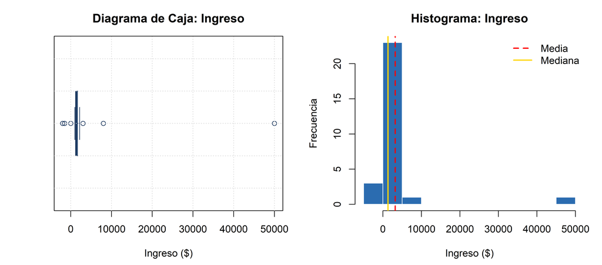

```r
# Gráficos integrados lado a lado: Diagrama de Caja e Histograma
par(mfrow = c(1, 2), mar = c(4.5, 4.5, 3, 1.5))

# 1. Diagrama de caja
boxplot(data$Ingreso,
        horizontal = TRUE,
        col = col_secondary,
        border = col_dark,
        main = "Diagrama de Caja: Ingreso",
        xlab = "Ingreso ($)")
grid(col = "gray85", lty = "dotted")

# 2. Histograma
hist(data$Ingreso,
     col = col_primary,
     border = "white",
     main = "Histograma: Ingreso",
     xlab = "Ingreso ($)",
     ylab = "Frecuencia",
     breaks = 15)
abline(v = mean(data$Ingreso, na.rm = TRUE), col = "red", lwd = 2, lty = 2)
abline(v = median(data$Ingreso, na.rm = TRUE), col = "gold", lwd = 2, lty = 1)
legend("topright", legend = c("Media", "Mediana"), col = c("red", "gold"), lty = c(2, 1), lwd = 2, bty = "n")
```

```r
par(mfrow = c(1, 1))
```

## 3.2 Variable: `Edad`

```
##    Min. 1st Qu.  Median    Mean 3rd Qu.    Max.     NAs
##   22.00   25.75   29.50   38.29   37.25  200.00       2
```

### 3.2.1 Tabla de Estadísticos Descriptivos

| Medida Estadística | Valor Observado | Diagnóstico e Interpretación Analítica |
| --- | --- | --- |
| **Mínimo** | 22.00 | Observación más joven; valor biológicamente consistente. |
| **Primer Cuartil ($Q_1$)** | 25.75 | El 25% de los individuos tiene 25.75 años o menos. |
| **Mediana ($Q_2$)** | **29.50** | Mediana central del grupo de estudio. |
| **Media Aritmética** | **38.29** | Distorsionada al alza por la presencia de un outlier biológicamente imposible. |
| **Tercer Cuartil ($Q_3$)** | 37.25 | El 75% tiene 37.25 años o menos. |
| **Máximo** | **200.00** | 🚨 **Error biológico inadmisible:** Error flagrante de captura de datos. |
| **Valores Nulos ($NA$)** | 2 | Dos registros sin registro de edad. |

🚨 Diagnóstico: El valor atípico 200 infla artificialmente la media

El registro de 200 años incrementa el promedio muestral en más de 6 años ($\approx 38.3$ vs $\approx 32.3$ años al removerlo). Siguiendo la regla de Tukey, el límite superior teórico se fija en $54.5$ años ($37.25 + 1.5 \times 11.5$). Todo valor superior a $100$ debe ser catalogado como error de digitación.

### 3.2.2 Comportamiento Gráfico

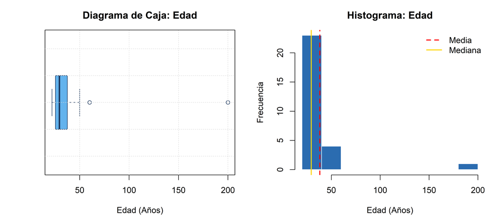

```r
par(mfrow = c(1, 2), mar = c(4.5, 4.5, 3, 1.5))

boxplot(data$Edad,
        horizontal = TRUE,
        col = col_secondary,
        border = col_dark,
        main = "Diagrama de Caja: Edad",
        xlab = "Edad (Años)")
grid(col = "gray85", lty = "dotted")

hist(data$Edad,
     col = col_primary,
     border = "white",
     main = "Histograma: Edad",
     xlab = "Edad (Años)",
     ylab = "Frecuencia",
     breaks = 12)
abline(v = mean(data$Edad, na.rm = TRUE), col = "red", lwd = 2, lty = 2)
abline(v = median(data$Edad, na.rm = TRUE), col = "gold", lwd = 2, lty = 1)
legend("topright", legend = c("Media", "Mediana"), col = c("red", "gold"), lty = c(2, 1), lwd = 2, bty = "n")
```

```r
par(mfrow = c(1, 1))
```

## 3.3 Variable: `Hijos`

```
##    Min. 1st Qu.  Median    Mean 3rd Qu.    Max.
##  0.0000  0.0000  0.0000  0.9667  2.0000  4.0000
```

### 3.3.1 Tabla de Estadísticos Descriptivos

| Medida Estadística | Valor Observado | Diagnóstico e Interpretación Analítica |
| --- | --- | --- |
| **Mínimo** | 0.00 | Presencia de individuos sin hijos. |
| **Primer Cuartil ($Q_1$)** | 0.00 | Al menos el 25% no tiene hijos. |
| **Mediana ($Q_2$)** | **0.00** | Moda y valor central: más del 50% de la muestra no tiene descendencia. |
| **Media Aritmética** | 0.97 | Promedio aproximado de 1 hijo por individuo en la muestra total. |
| **Tercer Cuartil ($Q_3$)** | 2.00 | El 75% tiene 2 hijos o menos. |
| **Máximo** | 4.00 | Cifra máxima plausible (4 hijos). |
| **Valores Nulos ($NA$)** | 0 | Variable completamente diligenciada ($n=30$). |

💡 Diagnóstico de Distribución: Asimetría Natural sin Outliers

La asimetría positiva en este caso es un fenómeno demográfico normal (alta proporción de adultos jóvenes solteros sin hijos). El límite de Tukey ($2 + 1.5 \times 2 = 5$) confirma que no existen valores atípicos en esta variable.

### 3.3.2 Comportamiento Gráfico

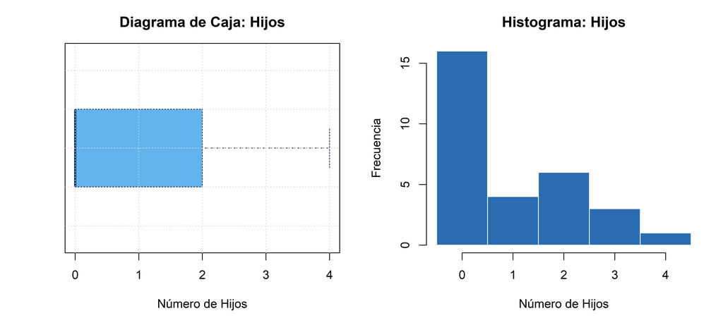

```r
par(mfrow = c(1, 2), mar = c(4.5, 4.5, 3, 1.5))

boxplot(data$Hijos,
        horizontal = TRUE,
        col = col_secondary,
        border = col_dark,
        main = "Diagrama de Caja: Hijos",
        xlab = "Número de Hijos")
grid(col = "gray85", lty = "dotted")

hist(data$Hijos,
     col = col_primary,
     border = "white",
     main = "Histograma: Hijos",
     xlab = "Número de Hijos",
     ylab = "Frecuencia",
     breaks = seq(-0.5, 4.5, by = 1))
```

```r
par(mfrow = c(1, 1))
```

# 4 Diagnóstico de Integridad: Nulos y Duplicados

## 4.1 Análisis de Valores Faltantes ($NA$)

```
## [1] "Total general de celdas vacías (NA): 4"
```

A continuación se discrimina la presencia de valores nulos por columna:

```r
library(dplyr)

na_por_columna <- colSums(is.na(data))

tabla_na <- data.frame(
  Columna = names(na_por_columna),
  Datos_Perdidos = na_por_columna
)

tabla_na_ordenada <- tabla_na %>%
  filter(Columna != "Total") %>%
  arrange(desc(Datos_Perdidos)) %>%
  rbind(data.frame(Columna = "TOTAL GENERAL", Datos_Perdidos = total_na))

knitr::kable(tabla_na_ordenada, align = c("l", "c"), caption = "Conteo de valores faltantes clasificados por variable")
```

Conteo de valores faltantes clasificados por variable

|  | Columna | Datos_Perdidos |
| --- | --- | --- |
| Edad | Edad | 2 |
| Ingreso | Ingreso | 2 |
| ID | ID | 0 |
| Nombre | Nombre | 0 |
| Apellido | Apellido | 0 |
| Genero | Genero | 0 |
| Ciudad | Ciudad | 0 |
| Profesion | Profesion | 0 |
| Nivel_Educativo | Nivel_Educativo | 0 |
| Estado_Civil | Estado_Civil | 0 |
| Hijos | Hijos | 0 |
| Email | Email | 0 |
| 1 | TOTAL GENERAL | 4 |

## 4.2 Análisis de Filas Duplicadas

```r
# Identificación de registros duplicados excluyendo el ID secuencial
duplicate_por_columna <- sapply(data, function(x) sum(duplicated(data)))
total_duplicate <- sum(duplicated(data[,-1]))
```

Visualización de las filas duplicadas identificadas en el dataset original:

```r
filas_repetidas <- data[c(1, 7, 30), ]
knitr::kable(filas_repetidas, caption = "Observaciones duplicadas identificadas correspondientes al usuario Juan Pérez")
```

Observaciones duplicadas identificadas correspondientes al usuario Juan Pérez

|  | ID | Nombre | Apellido | Edad | Ingreso | Genero | Ciudad | Profesion | Nivel_Educativo | Estado_Civil | Hijos | Email |
| --- | --- | --- | --- | --- | --- | --- | --- | --- | --- | --- | --- | --- |
| 1 | 1 | Juan | Pérez | 25 | 1200 | MASCULINO | Bogotá | Ingeniero | Universitario | SOLTERO | 0 | juanp@gmail.com |
| 7 | 7 | Juan | Pérez | 25 | 1200 | MASCULINO | Bogotá | Ingeniero | Universitario | SOLTERO | 0 | juanp@gmail.com |
| 30 | 30 | Juan | Pérez | 25 | 1200 | MASCULINO | Bogotá | Ingeniero | Universitario | SOLTERO | 0 | juanp@gmail.com |

Procedemos a descartar las filas duplicadas conservando la primera ocurrencia:

```r
# Eliminación de duplicados considerando todas las variables salvo ID
data_sin <- data[!duplicated(data[,-1]), ]
dim(data_sin)
```

```
## [1] 28 12
```

> **Resultado:** La matriz pasa de 30 a **28 filas**, eliminando las 2 ocurrencias redundantes.

# 5 Pipeline de Limpieza y Estandarización

## 5.1 Eliminación de Registros con Valores Faltantes ($NA$)

```r
data_limpia <- na.omit(data_sin)
dim(data_limpia)
```

```
## [1] 24 12
```

> **Resultado:** Tras suprimir observaciones incompletas, el conjunto de datos cuenta con **24 observaciones**.

## 5.2 Estandarización de Variables Cualitativas

Se aplica un proceso de limpieza de texto que homogeniza el formato a **Title Case** (primera letra en mayúscula y restantes en minúsculas) y elimina tildes/caracteres especiales mediante `iconv()`:

```r
vars_cualitativas <- c(
  "Nombre",
  "Apellido",
  "Genero",
  "Ciudad",
  "Profesion",
  "Nivel_Educativo",
  "Estado_Civil",
  "Email"
)

# Remoción de tildes y ajuste de mayúsculas/minúsculas
data_limpia[vars_cualitativas] <- lapply(
  data_limpia[vars_cualitativas],
  function(x) {
    x <- as.character(x)
    x <- tolower(x)
    x <- iconv(x, from = "UTF-8", to = "ASCII//TRANSLIT")
    paste0(
      toupper(substr(x, 1, 1)),
      substr(x, 2, nchar(x))
    )
  }
)
```

### 5.2.1 Verificación de Frecuencias tras Estandarización

```r
tabla_limpia_Nivel_Educativo <- data.frame(sort(table(data_limpia$Nivel_Educativo), decreasing = TRUE))
colnames(tabla_limpia_Nivel_Educativo) <- c("Nivel Educativo", "Frecuencia")
knitr::kable(tabla_limpia_Nivel_Educativo, align = c("l", "c"), caption = "Nivel Educativo Estandarizado")
```

Nivel Educativo Estandarizado

| Nivel Educativo | Frecuencia |
| --- | --- |
| Universitario | 13 |
| Especializacion | 5 |
| Maestria | 4 |
| Bachiller | 2 |

```r
tabla_limpia_Genero <- data.frame(sort(table(data_limpia$Genero), decreasing = TRUE))
colnames(tabla_limpia_Genero) <- c("Género", "Frecuencia")
knitr::kable(tabla_limpia_Genero, align = c("l", "c"), caption = "Género Estandarizado (Niveles Unificados)")
```

Género Estandarizado (Niveles Unificados)

| Género | Frecuencia |
| --- | --- |
| Masculino | 13 |
| Femenino | 11 |

```r
tabla_limpia_Ciudad <- data.frame(sort(table(data_limpia$Ciudad), decreasing = TRUE))
colnames(tabla_limpia_Ciudad) <- c("Ciudad", "Frecuencia")
knitr::kable(tabla_limpia_Ciudad, align = c("l", "c"), caption = "Ciudad Estandarizada (Bogotá Homologada)")
```

Ciudad Estandarizada (Bogotá Homologada)

| Ciudad | Frecuencia |
| --- | --- |
| Bogota | 10 |
| Cali | 8 |
| Medellin | 6 |

## 5.3 Homologación Semántica: `Estado_Civil`

Se unifican las categorías correspondientes al género gramatical (*Casado/Casada* $\rightarrow$ **Casado**; *Soltero/Soltera* $\rightarrow$ **Soltero**):

```r
data_limpia$Estado_Civil_Limpio <- ifelse(
  tolower(data_limpia$Estado_Civil) %in% c("casado", "casada"),
  "Casado",
  ifelse(
    tolower(data_limpia$Estado_Civil) %in% c("soltero", "soltera"),
    "Soltero",
    data_limpia$Estado_Civil
  )
)

knitr::kable(as.data.frame(table(data_limpia$Estado_Civil_Limpio)),
             col.names = c("Estado Civil Homologado", "Frecuencia"),
             align = c("l", "c"),
             caption = "Distribución consolidada de Estado Civil")
```

Distribución consolidada de Estado Civil

| Estado Civil Homologado | Frecuencia |
| --- | --- |
| Casado | 11 |
| Soltero | 11 |
| Union libre | 2 |

## 5.4 Depuración de Inconsistencias y Errores Lógicos

A continuación se auditan y filtran los registros con incongruencias biológicas o económicas:

### 5.4.1 1. Registros con ingresos no válidos ($\le 0$)

```r
knitr::kable(data_limpia[data_limpia$Ingreso <= 0, ], caption = "Inconsistencia de Ingreso detectada (Pedro y Diego)")
```

Inconsistencia de Ingreso detectada (Pedro y Diego)

|  | ID | Nombre | Apellido | Edad | Ingreso | Genero | Ciudad | Profesion | Nivel_Educativo | Estado_Civil | Hijos | Email | Estado_Civil_Limpio |
| --- | --- | --- | --- | --- | --- | --- | --- | --- | --- | --- | --- | --- | --- |
| 5 | 5 | Pedro | Martinez | 35 | -2000 | Masculino | Bogota | Comerciante | Bachiller | Union libre | 3 | Pedro@gmail.com | Union libre |
| 12 | 12 | Diego | Ramirez | 50 | 0 | Masculino | Cali | Contador | Universitario | Casado | 2 | Diego@gmail.com | Casado |
| 21 | 21 | Pedro | Martinez | 35 | -1500 | Masculino | Bogota | Comerciante | Bachiller | Union libre | 3 | Pedro@gmail.com | Union libre |

### 5.4.2 2. Registros con edades imposibles ($\le 0$ o $\ge 100$)

```r
knitr::kable(data_limpia[data_limpia$Edad <= 0 | data_limpia$Edad >= 100, ], caption = "Inconsistencia de Edad detectada (Ricardo: 200 años)")
```

Inconsistencia de Edad detectada (Ricardo: 200 años)

|  | ID | Nombre | Apellido | Edad | Ingreso | Genero | Ciudad | Profesion | Nivel_Educativo | Estado_Civil | Hijos | Email | Estado_Civil_Limpio |
| --- | --- | --- | --- | --- | --- | --- | --- | --- | --- | --- | --- | --- | --- |
| 28 | 28 | Ricardo | Acosta | 200 | 3000 | Masculino | Cali | Empresario | Maestria | Casado | 4 | Ricardo@gmail.com | Casado |

### 5.4.3 3. Registros con número implausible de hijos

```r
knitr::kable(data_limpia[data_limpia$Hijos < 0 | data_limpia$Hijos >= 12, ], caption = "Auditoría de Hijos (sin inconsistencias)")
```

Auditoría de Hijos (sin inconsistencias)

| ID | Nombre | Apellido | Edad | Ingreso | Genero | Ciudad | Profesion | Nivel_Educativo | Estado_Civil | Hijos | Email | Estado_Civil_Limpio |
| --- | --- | --- | --- | --- | --- | --- | --- | --- | --- | --- | --- | --- |

### 5.4.4 Creación del dataset sin errores lógicos

Se eliminan las filas con anomalías evidentes:

```r
data_sin_errores <- data_limpia[
  !(data_limpia$Edad <= 0 | data_limpia$Edad > 100 | data_limpia$Ingreso < 0),
]
dim(data_sin_errores)
```

```
## [1] 21 13
```

# 6 Detección y Tratamiento Formal de Outliers

## 6.1 Fundamentación Matemática: Método del Rango Intercuartílico (IQR)

Para la identificación de datos atípicos (*outliers*) se empleó el método del **Rango Intercuartílico (IQR)**, una metodología no paramétrica y robusta frente a distribuciones asimétricas al sustentarse en medidas de posición (cuartiles).

El procedimiento se fundamenta en establecer la dispersión del 50% central de los datos mediante:

$$\text{IQR} = Q_3 - Q_1$$

A partir de este rango de dispersión, se definen los umbrales de normalidad analítica de Tukey:

$$\text{Límite Inferior} = Q_1 - 1.5
\times \text{IQR}$$
$$\text{Límite
Superior} = Q_3 + 1.5 \times \text{IQR}$$

Cualquier observación $x_i$ que cumpla $x_i < \text{Límite Inferior}$ o $x_i > \text{Límite Superior}$ se cataloga formalmente como un **valor atípico moderado**, mientras que aquellas que sobrepasen $3 \times \text{IQR}$ corresponden a **valores extremos**.

## 6.2 Detección en la Variable `Ingreso`

```r
# Cálculo de cuartiles y rango intercuartílico
Q1 <- quantile(data_sin_errores$Ingreso, 0.25)
Q3 <- quantile(data_sin_errores$Ingreso, 0.75)
IQR_valor <- IQR(data_sin_errores$Ingreso)

# Definición de límites de corte
limite_inferior <- Q1 - 1.5 * IQR_valor
limite_superior <- Q3 + 1.5 * IQR_valor

# Identificación de observaciones atípicas
valores_atipicos <- data_sin_errores[
  data_sin_errores$Ingreso < limite_inferior |
  data_sin_errores$Ingreso > limite_superior,
]

knitr::kable(valores_atipicos, caption = "Valores Atípicos identificados en la variable Ingreso")
```

Valores Atípicos identificados en la variable Ingreso

|  | ID | Nombre | Apellido | Edad | Ingreso | Genero | Ciudad | Profesion | Nivel_Educativo | Estado_Civil | Hijos | Email | Estado_Civil_Limpio |
| --- | --- | --- | --- | --- | --- | --- | --- | --- | --- | --- | --- | --- | --- |
| 3 | 3 | Carlos | Lopez | 45 | 3000 | Masculino | Cali | Medico | Maestria | Casado | 2 | Carlosl@gmail.com | Casado |
| 8 | 8 | Andres | Garcia | 40 | 50000 | Masculino | Medellin | Empresario | Maestria | Casado | 2 | Andres@gmail.com | Casado |
| 12 | 12 | Diego | Ramirez | 50 | 0 | Masculino | Cali | Contador | Universitario | Casado | 2 | Diego@gmail.com | Casado |
| 15 | 15 | Miguel | Ortega | 60 | 8000 | Masculino | Cali | Administrador | Maestria | Casado | 3 | Miguel@gmail.com | Casado |

```r
data_sin_errores <- data_sin_errores[
  data_sin_errores$Ingreso >= limite_inferior &
  data_sin_errores$Ingreso <= limite_superior,
]

summary(data_sin_errores$Ingreso)
```

```
##    Min. 1st Qu.  Median    Mean 3rd Qu.    Max.
##    1000    1200    1300    1379    1500    2200
```

```r
dim(data_sin_errores)
```

```
## [1] 17 13
```

# 7 Transformación y Escalado de Características

## 7.1 Estandarización (*Z-Score*)

La **estandarización** o reescalamiento *Z-score* transforma las variables cuantitativas continuas para que compartan una escala común con media $\mu = 0$ y varianza unitaria $\sigma^2 = 1$.

Para cada observación $x_i$, su puntuación estandarizada se define matemáticamente como:

$$z_i = \frac{x_i -
\bar{x}}{s}$$

Donde los estimadores muestrales de media ($\bar{x}$) y desviación estándar insesgada ($s$) se definen por:

$$\bar{x} = \frac{1}{n} \sum_{i=1}^{n} x_i
\qquad \text{y} \qquad s = \sqrt{\frac{1}{n - 1} \sum_{i=1}^{n} (x_i -
\bar{x})^2}$$

📘 Relevancia en Modelos de Inteligencia Artificial

Este paso es fundamental antes de entrenar algoritmos sensibles a la magnitud o basados en funciones de distancia euclidiana (como *K-Means*, *PCA*, *KNN*, *SVM* o Redes Neuronales Artificiales), previniendo que variables con escalas nominales mayores dominen indebidamente el aprendizaje.

### 7.1.1 Aplicación en R:

```r
# Escalamiento Z-Score
data_sin_errores$Ingreso_est <- as.vector(scale(data_sin_errores$Ingreso))

summary(data_sin_errores$Ingreso_est)
```

```
##    Min. 1st Qu.  Median    Mean 3rd Qu.    Max.
## -1.3546 -0.6405 -0.2835  0.0000  0.4305  2.9296
```

### 7.1.2 Visualización del Ingreso Estandarizado

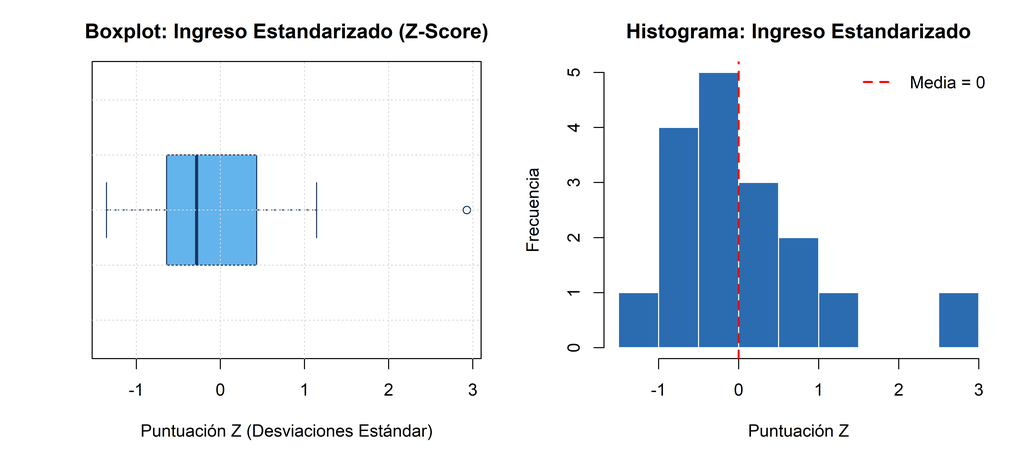

```r
par(mfrow = c(1, 2), mar = c(4.5, 4.5, 3, 1.5))

boxplot(data_sin_errores$Ingreso_est,
        horizontal = TRUE,
        col = col_secondary,
        border = col_dark,
        main = "Boxplot: Ingreso Estandarizado (Z-Score)",
        xlab = "Puntuación Z (Desviaciones Estándar)")
grid(col = "gray85", lty = "dotted")

hist(data_sin_errores$Ingreso_est,
     col = col_primary,
     border = "white",
     main = "Histograma: Ingreso Estandarizado",
     xlab = "Puntuación Z",
     ylab = "Frecuencia",
     breaks = 10)
abline(v = 0, col = "red", lwd = 2, lty = 2)
legend("topright", legend = c("Media = 0"), col = "red", lty = 2, lwd = 2, bty = "n")
```

```r
par(mfrow = c(1, 1))
```

## 7.2 Normalización *Min-Max*

La normalización *Min-Max* es una técnica lineal que proyecta el rango de una variable cuantitativa hacia un intervalo cerrado acotado, típicamente $[0, 1]$:

$$x'_i = \frac{x_i - \min(X)}{\max(X)
- \min(X)}$$

Para escalar hacia un rango genérico arbitrario $[a, b]$, la expresión general adopta la forma:

$$x'_i = a + \frac{(x_i - \min(X))(b -
a)}{\max(X) - \min(X)}$$

```r
# Normalización Min-Max al rango [0, 1]
data_sin_errores$Ingreso_norm <- (
  data_sin_errores$Ingreso - min(data_sin_errores$Ingreso)
) / (max(data_sin_errores$Ingreso) - min(data_sin_errores$Ingreso))

summary(data_sin_errores$Ingreso_norm)
```

```
##    Min. 1st Qu.  Median    Mean 3rd Qu.    Max.
##  0.0000  0.1667  0.2500  0.3162  0.4167  1.0000
```

## 7.3 Transformaciones para Corrección de Asimetría

Cuando una variable presenta un sesgo pronunciado a la derecha (*positive skewness*), se aplican transformaciones no lineales para estabilizar la varianza y aproximar el comportamiento de los residuos a la normalidad:

1. **Transformación Logarítmica:** Comprime valores elevados y expande los inferiores ($x_i > 0$):
   $$y_i = \ln(x_i) \qquad \text{o
   bien} \qquad y_i = \ln(x_i + 1)$$
2. **Transformación de Raíz Cuadrada:** Alternativa moderada ideal para variables de conteo ($x_i \ge 0$):
   $$y_i =
   \sqrt{x_i}$$
3. **Transformación de Box-Cox:** Familia paramétrica generalizada en función de un parámetro $\lambda$ estimado por máxima verosimilitud ($x_i > 0$):
   $$y_i(\lambda) = \begin{cases} \dfrac{x_i^\lambda -
   1}{\lambda} & \text{si } \lambda \neq 0 \\[10pt] \ln(x_i) &
   \text{si } \lambda = 0 \end{cases}$$

# 8 Exportación del Dataset Depurado

Una vez finalizado el ciclo integral de auditoría, limpieza, homologación y transformación, el conjunto de datos resultante se exporta a formato Excel en el directorio `RESULTADOS`:

```r
library(writexl)

# Exportación a formato Excel
write_xlsx(data_sin_errores, "../RESULTADOS/datafinal.xlsx")
```

🎉 Proceso de Limpieza y Preprocesamiento Culminado Exitosamente

El archivo depurado final ha sido almacenado en `CLASE_1/RESULTADOS/datafinal.xlsx` con **17 observaciones** íntegras, variables estandarizadas, sin duplicados ni inconsistencias de captura.